# Introduction to RStudio

Nov 10 & 17, 2020

## Introduction of Presenters

## Akihito Kamata

- Southern Methodist University (2013 - )
  - Professor
    - Psychology
    - Education Policy and Leadership
  - Director of Graduate Studies
    - Simmons School of Education and Human Development
  - Executive Director
    - Center on Research and Evaluation

## Previously Held Positions

- Florida State University (1998 - 2009)
  - Assistant & Associate Professor
  - Department Chair
    - Educational Psychology & Learning Systems
- University of Oregon (2009 - 2013)
  - Professor
  - Department Head
    - Educational Methodology, Policy & Leadership

## Yusuf Kara

- Southern Methodist University (2014-15, 2017 - )
  - Senior Program Manager
    - Center on Research and Evaluation

## Previously Held Positions

- Anadolu University, Turkey (2013-2018)
  - Research Faculty
    - Department of Educational Measurement and Evaluation
    - Department of Distance Education, Learning Technologies
- Middle East Technical University, Turkey (2012-2013)
  - Program Advisor
    - State University of New York (SUNY) Coordination Office

## Recent Work

- Oral Reading Fluency (ORF) Assessment
  - We are developing an R package for estimating passage parameters and students’ ORF scores.
  - 3-year Research Grant from IES: U.S. Department of Education.
    - Akihito Kamata, SMU (PI)
    - Yusuf Kara, SMU (co-PI)
    - Cornelis Potgieter, TCU (co-PI)
    - Joseph Nese, University of Oregon (co-PI)

## Okay, Let’s talk about R now!

## What Can We Do with R and RStudio?

- Statistical Analysis
- Data visualizations
- Data Manipulations and Management
- Generating Documents
  - HTML files
    - Documents to share your work with others (example)
    - Slides (example - this slide set!)
  - PDF files
    - Documents and slides (example)
    - APA formatted manuscripts (example)
- Websites: [(example)](https://kamataak.github.io/qmlweb/about.html)
- Shiny Apps [(website for Shiny)](https://shiny.rstudio.com/)
- Dashboard [(website for flexboard for R)](https://rmarkdown.rstudio.com/flexdashboard/index.html)
- Collaboration on GitHub

## Let’s get started!

## Materials

- All materials including this slide set are available at:
  - https://github.com/kamataak/WorkshopSMU2020
- Download all materials.
  - Click on “Code”.
    - If you know how to use Git, clone it!
  - Otherwise, click on “Download ZIP”.
    - The entire folder will be downloaded to your download folder as a compressed ZIP file.
    - Move the ZIP file where you desire.
    - Unzip the folder.

## Download R

- Download R from the R-Project website.
  - http://www.r-project.org
  - Follow the links to go to the download page.
    - Go to “CRAN”
    - Then, choose one of the links, such as one under “0-Cloud”.
  - R is available for Windows, Mac OS, and Linux platforms.

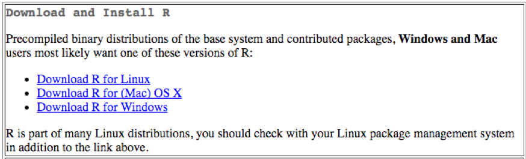

## Install R

- Currently, a stable version is 4.02.
- Run the downloaded installer to install R, and follow the instructions.
  - You can accept all default specifications.

## Download & Install RStudio

- Download from RStudio website.
  - https://rstudio.com/products/rstudio/download/
  - Download the free version.
- Then, install RStudio by running the downloaded installer.
- When installation of RStudio is completed, be sure that it opens with R in the console pane.

## Part 1: Workflow on RStudio

## Recommended Work Management on RStudio

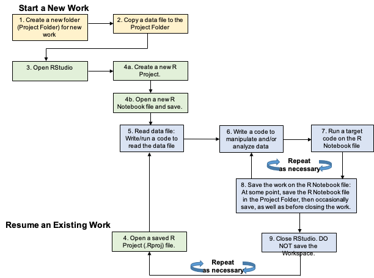

## Steps: 1 & 2 Preparation of Project Folder

- Create a new folder. This is will become a Project Folder.
- Copy the data file to analyze to this Project Folder.
  - For this demonstration, download a CSV data from: https://bit.ly/3cJcU08
  - For a realistic situation, you will copy a necessary data file into this folder.

## Step 3: Open RStudio

- Open RStudio, just like opening other programs on your computer.
- It will automatically link to R.

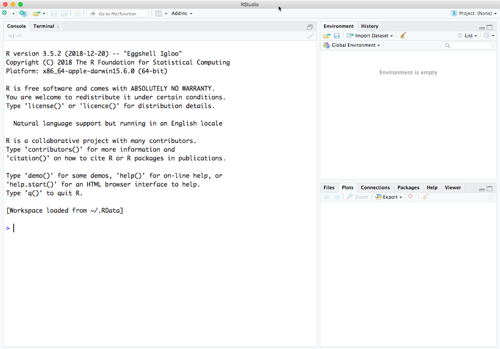

## Step 4a: Create a New R Project

- At this point, the project name says “Project (None)” on the upper right corner.
  - This indicates that no project is open yet on this RStudio window.
- Click on “Create a Project” button.
  - Click on “Existing Directory”.
  - Then, click on “Browse…” and select the target Project Folder, where the data file was copied.
  - Click on “Create Project”.

[figure not shown]

[figure not shown]

- Now, you will have RStudio open with a new project.
  - Notice the label for the project on the upper right corner has changed.
- Notice that a new file with .Rproj has been created in the project folder.
  - This is a project file, and will store information about the project.
  - Also, when you resume your work for this project, you will double click this file to open RStudio and the project.

## Step 4a: Install Required Packages

- I have already installed some key packages.
- Note:
  - R comes with only limited set of base packages.
    - To do something realistic, we almost always need to use other packages.
    - Also, usability of R can be dramatically enhanced by additional packages.
  - In practical use of R in research, one would constantly look for a solution.
    - A solution is likely to require a package to be installed.
- I have installed:
  - **`tidyverse`**
    - A collection of several packages for data manipulations and visualizations.
    - We can use so many functions and features in packages available from this package.
- I have also installed:
  - **`sjmisc`**
    - A package that offers additional data manipulation utilities.
    - Also, it comes with nice functions to generate a frequency table and descriptive statistics.
  - **`sjlabelled`**
    - Collection of functions dealing with labelled data, like reading and writing data between R and other statistical software packages like ‘SPSS’, ‘SAS’ or ‘Stata’, and working with labelled data.

## Step 4b: Open a New R Notebook

- Choose an “**R Notebook**” option from the pull-down menu on the button right under the “File” menu.

[figure not shown]

- Then, a new R Notebook file “**Untitled1**” will be open.
  - The file is populated with a template, which contains some suggested shortcut keys.

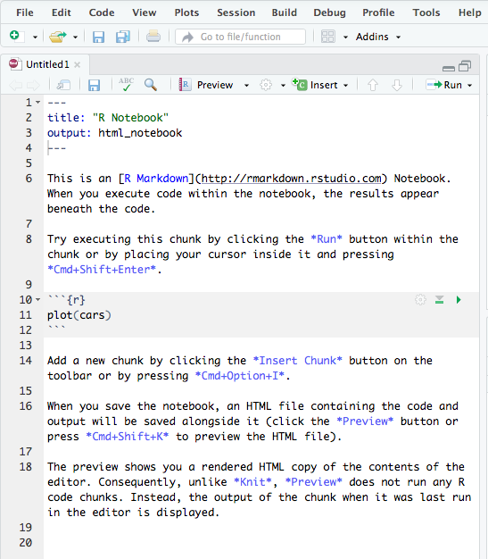

- Erase all contents, except lines 1 - 4.

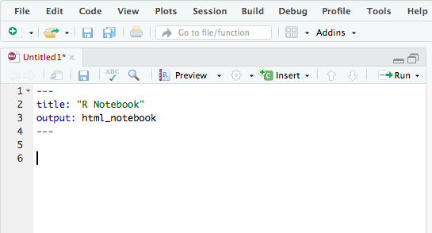

- We are ready to go!
- Let’s name this R Notebook file with a meaningful name.
  - Click on the diskette-shape icon, right below the "Untitle1*" tab.

Note: When your work has not been saved, you see the R Notebook tab in red with asterisk.

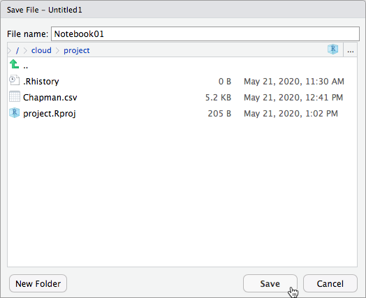

- Type a file name, say “**Notebook01**”.
- Then, click on “**Save**”.

[figure not shown]

- Notice two files has been created:
  - **Notebook01.Rmd**
    - This is the R Notebook file we are working on.
  - **Notebook01.nb.html**
    - This is an HTML file to output the content and results of the R Notebook file.
- Let’s take a peek the HTML file.
  - Click the file name of the HTML file.
  - Choose “**View in Web Browser**”.

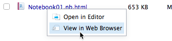

[figure not shown]

- Quite empty for now…
- Let’s add & edit some information in the first few lines and **save**:

[figure not shown]

Note:

- The first few lines tagged by three dashes “- - -” is called YAML header.
- R Notebook updates the HTML file every time we **save** the Notebook file.

[figure not shown]

- Very nice!
- The next step is to add some R code and comments to the R Notebook file.

## Step 5a: Load Required Packages

- Required packages have been installed.
- However, required packages need to be loaded every time we start a session.
  - **Installing** and **loading** a package are two different things.
- Let’s write a code to load required packages.
- Create a new code chunk.
  - Choose **R**, under the “**Insert**” button.
    - Alternatively, **option + command + I** shortcut keys.

[figure not shown]

[figure not shown]

- Code chunk is where we write R code.
- We can write comments outside of code chunk.
- Line 8: Add a comment outside of the code chunk.
- Line 9: Add a specification not to output messages. [Optional]
- Lines 10-11: Write two new lines of R code to load two packages:
  - **`tidyverse`** for reading an CSV format data, as well as for data manipulations.
  - **`sjmisc`** for generating a frequency table.

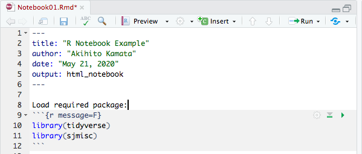

- To run this code chunk, click on the green arrow on the upper-right corner of the code chunk (gray-shaded area).

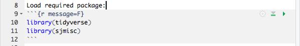

## Step 5a: Read Data File

- Place a cursor on line 15, and create another code chunk. Then,
  - Line 14: Add a comment outside of the code chunk.
  - Line 15: Add a specification not to output messages. [Optional]
  - Lines 16-17: Write 2 new lines of R code:
    - To read the data file into a data object **Chapman.dat** (line 16)
    - To display the data object (line 17)

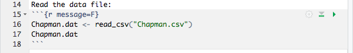

- Run this code chunk by clicking on the green arrow on the upper-right corner of the code chunk.

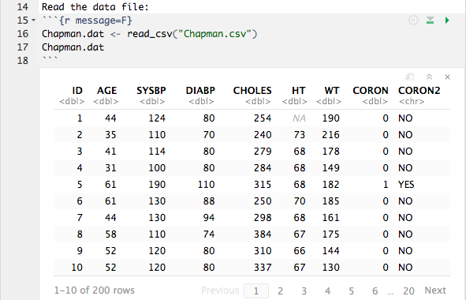

- Also, the data object will appear in the “**Environment**” tab in the upper-right pane.

[figure not shown]

- As another way to view the data, we can click on the data object name in the “Environment” tab.

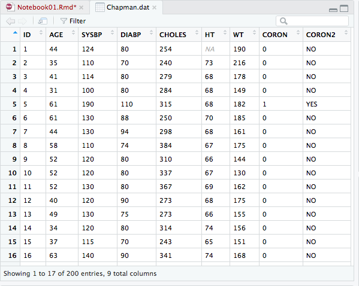

- This is just a data viewer, and we cannot edit the data on the viewer.
  - We can still sort and filter the data to explore the data.
- By now, we have a nice **Notebook** to show R codes, comments, and output.
  - This is a nice way to build and manage your work.
    - Write R code and run.
    - See results.
    - Write comments.
- Recall that we also have an HTML file produced by the Notebook file.
  - Save the Notebook file, and check the HTML file.

[figure not shown]

## Steps 6-8: Do Something with Data

- Let’s generate a frequency table for the variable `CORON2`.
  1. Create a new R code chunk.
  2. Select the variable `CORON2` by the **`select`** function.
     - This function is from `dplyr` package as part of **`tidyverse`** package.
  3. Use **`frq`** function to generate a frequency table.
     - This function is from **`sjmisc`** package.

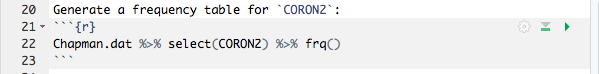

- **`%>%`** is called a pipe operator, which is part of **`tidyverse`** package.
  - In short, the left-hand side of **`%>%`** will be passed to the right-hand side as the first entry of the function.
  - It is extremely useful for executing multiple operations sequentially.

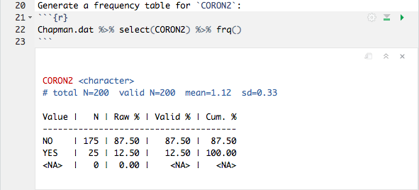

- Let’s save the Notebook file and check the HTML file.

## Step 9: Close Project

- Be sure to save your Notebook file for the last time.
- It is highly recommended NOT to save the “workspace”, because you can easily replicate your work by running the saved syntax.

## Resuming Existing Work

- Step 4: Open RStudio by double-clicking a saved R Project file (.Rproj file).
  - The target R script file will be automatically open, if it was open when you closed RStudio last time.
  - Otherwise, go to “Files” tab of RStudio, and click the target R script file name to open.
- Step 5: Run all code chunks.
  - Run one by one by clicking green arrows.
  - Or select “**Run All**” from “**Run**” button.

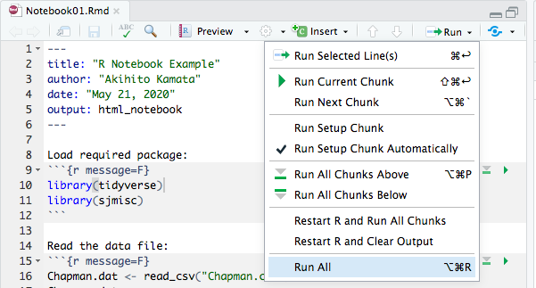

- Now you are back to where you were.
  - You can develop additional work.

## Let’s Do It 1

- Replicate what have been demonstrated:
  1. Create a new folder **`FirstRprojedt`**, and copy the data file **`Chapman.csv`**.
  2. Open RStudio, and create a new project for the newly created folder.
  3. Install `tidyverse` package, if you have not.
  4. Open a new script file, and write lines to read the `Chapman.csv` data as `Chapman.dat`.
  5. Save the R script file by naming it **`FirstRscript`**.
  6. Close RStudio.
  7. Re-open RStudio by double-clicking **`FirstRproject.Rproj`**.

## Let’s Do It 2

- Learn about how to do some data manipulations.
  1. Create a new folder **`DataTransformations`**, and download data files **`easyCBM.csv`** and **`easyCBM.sav`**.
  2. Also, download an R Notebook Rmd file **`02_DataTransformations.Rmd`** to the folder.
  3. Open RStudio, and create a new project for this newly created folder.
  4. Install `sjmisc` and `sjlabelled` packages, if you have not.
  5. Open the R Notebook Rmd file `02_DataTransformations.Rmd`.
  6. Study each code chunk and run.

## Let’s Do It 3

- Learn about how to generate some descriptive statistics.
  1. Create a new folder **`DescriptiveStatistics`**, and copy a data file **`easyCBM.sav`**.
  2. Also, download an R Notebook Rmd file **`05_DescriptiveStat1.Rmd`** to the folder.
  3. Open RStudio, and create a new project for this newly created folder.
  4. Install `psych` package, if you have not.
  5. Open the R Notebook Rmd file `05_DescriptiveStat1.Rmd`.
  6. Study each code chunk and run.